## Qualitive Activity Recognition of Weight Lifting Exercises

### Johns Hopkins University - Coursera Practical Machine Learning course

#### Final assignment by RobDat18, March 2019

### Abstract

The weight-lifting data graciously provided by the [Human Activity Recognition website](http://web.archive.org/web/20161224072740/http:/groupware.les.inf.puc-rio.br/har) are used to develop a prediction model for five different weight-lifting classifications. The model which is based on a random forest technique, features a 0.997 prediction accuracy.

### The Assignment Goal

Six participants were asked to perform dumbell lifts correctly and incorrectly in 5 different ways:  
- Class A: exactly according to the specification,  
- Class B: throwing the elbows to the front,  
- Class C: lifting the dumbbell only halfway,  
- Class D: lowering the dumbbell only halfway and  
- Class E: throwing the hips to the front.

The goal of this assignment is to predict the manner in which these participants did the exercises. All variables in the *pml-training* data set may be used to do so. The final prediction model shall be used to predict 20 different test cases in the *pml-testing* data set.

### Raw Data downoading and cleaning

```r
file1 <- "https://d396qusza40orc.cloudfront.net/predmachlearn/pml-training.csv"
download.file (file1, destfile = "pml-training.csv")
file2<- "https://d396qusza40orc.cloudfront.net/predmachlearn/pml-testing.csv"
download.file (file2, destfile = "pml-testing.csv")

PMLtraining <- as.data.frame(read.csv("pml-training.csv", header=TRUE, sep=",", quote=""))
PMLtesting <- as.data.frame(read.csv("pml-testing.csv", header=TRUE, sep=",", quote=""))

colnames(PMLtraining) <- gsub("[X\\..]","",colnames(PMLtraining))
colnames(PMLtraining)[1] <- "index"
colnames(PMLtesting) <- gsub("[X\\..]","",colnames(PMLtesting))
colnames(PMLtesting)[1] <- "index"
```

The PMLtraining data set contains 160 columns and 19622 rows, its last column ‘classe’ being the to-be-predicted outcome variable. The corresponding PMLtesting data features the same columns save the last one: the *classe* variable is missing, making this a *blind test* data set. It has only 20 rows (observations).

```r
dim(PMLtraining)
```

```
## [1] 19622   160
```

```r
dim(PMLtesting)
```

```
## [1]  20 160
```

A summary of the PMLtesting data reveals many columns containing just missing values (NA).

```r
summary(PMLtesting) # the output is hidden
```

It makes no sense to develop a prediction model based on variables / predictors which are missing in this testing data set. Therefore, these variables are removed from the model building (training) data set. Also, many other PMLtesting columns contain “” as a single, unique value, for all 20 rows. Checking their counterparts in the PMLtraining set shows that most of these column-values (>97%) are the same. The remaining values often include the “#Dev/0!” text string. It is therefore decided that all PMLtesting columns having a single unique value, NAs or “”, are to be removed from both data sets.

```r
# Data cleaning, creating the 'BaseData' and 'BlindTest' data sets.
#====================================================================================================

# Cleaning the values of the index variable / column.
PMLtraining$index <- str_trim(PMLtraining$index)          # stripping the index variable
PMLtraining$index <- gsub("[\\]","", PMLtraining$index)   # removing the \
PMLtraining$index <- gsub("[\"]","", PMLtraining$index)   # and the "-s
PMLtraining$index <- as.integer(PMLtraining$index)        # character to integer

PMLtesting$index <- str_trim(PMLtesting$index)          # stripping the index variable
PMLtesting$index <- gsub("[\\]","", PMLtesting$index)   # removing the \
PMLtesting$index <- gsub("[\"]","", PMLtesting$index)   # and the "-s
PMLtesting$index <- as.integer(PMLtesting$index)        # character to integer

# Selecting the columns in the 'PMLtesting' data set with just 1 unique value, incl. NAs.
# Removing these columns from both data sets.

w <- dim(PMLtesting)[2]         # The no.of columns of the 'PMLtesting' data set.
u <- rep(0, w)                  # Vector u with dummy values equal to zero.

for(i in 1: w){
    if(length(unique(PMLtesting[,i]))==1){
        u[i]<-i                 # PMLtesting columns with just 1 unique value: the column number
    }                           # is set in u at its corresponding column position.
}

BlindTest <- PMLtesting[,-u]  # Removing all 'PMLtesting' data set columns with just 1 unique value.
BaseData <- PMLtraining[,-u]  # Removing the same columns from 'PMLtraining' data set.

# Cleaning and converting the cvtd_timestamp variable into a date&time format.
BaseData$cvtd_timestamp <- gsub("[\"]","", BaseData$cvtd_timestamp) # removing "-s.
BaseData$cvtd_timestamp <- dmy_hm (BaseData$cvtd_timestamp)
BaseData$cvtd_timestamp <- as.POSIXct(BaseData$cvtd_timestamp)

BlindTest$cvtd_timestamp <- gsub("[\"]","", BlindTest$cvtd_timestamp) # removing "-s.
BlindTest$cvtd_timestamp <- dmy_hm (BlindTest$cvtd_timestamp)
BlindTest$cvtd_timestamp <- as.POSIXct(BlindTest$cvtd_timestamp)

BaseData$user_name <- gsub("[\"]","",BaseData$user_name)      # Removing the superfluous ""
BaseData$user_name <- as.factor(BaseData$user_name) # Renewed factorization of the 'user_name'.
BlindTest$user_name <- gsub("[\"]","",BlindTest$user_name)    # Removing the superfluous ""
BlindTest$user_name <- as.factor(BlindTest$user_name) # Renewed factorization of the 'user_name'

BaseData$classe <- gsub("[\"]","", BaseData$classe) # Removing the superfluous "" in the outcome
                                                    # variable (classe)values.
BaseData$classe <- as.factor(BaseData$classe)       # Renewed factorization of the 'classe' outcomes.
```

The resulting BaseData set is the slimmed-down version of the PMLtraining data set, containing 59 columns including the *classe* outcome variable. So 58 potential regressors remain. Column 2 (user_name) is a *factor* variable, column 5 (cvtd_timestamp) is *POSIXct*. All others are either *integer* or *numeric*.  
This concludes the downloading and data cleaning of the model building data set.

```r
str(BaseData)
```

```
## 'data.frame':    19622 obs. of  59 variables:
##  $ index               : int  1 2 3 4 5 6 7 8 9 10 ...
##  $ user_name           : Factor w/ 6 levels "adelmo","carlitos",..: 2 2 2 2 2 2 2 2 2 2 ...
##  $ raw_timestamp_part_1: int  1323084231 1323084231 1323084231 1323084232 1323084232 1323084232 1323084232 1323084232 1323084232 1323084232 ...
##  $ raw_timestamp_part_2: int  788290 808298 820366 120339 196328 304277 368296 440390 484323 484434 ...
##  $ cvtd_timestamp      : POSIXct, format: "2011-12-05 11:23:00" "2011-12-05 11:23:00" ...
##  $ num_window          : int  11 11 11 12 12 12 12 12 12 12 ...
##  $ roll_belt           : num  1.41 1.41 1.42 1.48 1.48 1.45 1.42 1.42 1.43 1.45 ...
##  $ pitch_belt          : num  8.07 8.07 8.07 8.05 8.07 8.06 8.09 8.13 8.16 8.17 ...
##  $ yaw_belt            : num  -94.4 -94.4 -94.4 -94.4 -94.4 -94.4 -94.4 -94.4 -94.4 -94.4 ...
##  $ total_accel_belt    : int  3 3 3 3 3 3 3 3 3 3 ...
##  $ gyros_belt_x        : num  0 0.02 0 0.02 0.02 0.02 0.02 0.02 0.02 0.03 ...
##  $ gyros_belt_y        : num  0 0 0 0 0.02 0 0 0 0 0 ...
##  $ gyros_belt_z        : num  -0.02 -0.02 -0.02 -0.03 -0.02 -0.02 -0.02 -0.02 -0.02 0 ...
##  $ accel_belt_x        : int  -21 -22 -20 -22 -21 -21 -22 -22 -20 -21 ...
```

[output cut: 45 more lines]

### Splitting the Data

The BaseData set is relatively large and a prediction-model based on a combination of prediction-methods is not to be precluded beforehand. Therefore, a validation set is introduced. In accordance with Jeff Leek’s guidelines for modeling large data sets, the BaseData observations (rows) are split into 60% training, 20% test and 20% validation.

```r
set.seed(1000)
inBuild <- createDataPartition (y=BaseData$classe, p=0.8, list=FALSE)
validation <- BaseData[-inBuild, ]
buildData <- BaseData[inBuild, ]
inTrain <- createDataPartition (y=buildData$classe, p=0.75, list=FALSE)
training <- buildData[inTrain, ]
testing <- buildData[-inTrain, ]
```

### Exploratory Data Analysis

The training data set is used for an exploratory analysis. This analysis quick-scans the potential regressors to understand if any data preprocessing is required and to establish potentially promissing modeling techniques. The *index* variable turns out to be a sequential categorization of the *classe*-based measurements. The three *timestamp* variables do indeed contain just timestamp data. These four variables will therefore be excluded as predictors in the regression model. A scan for near-zero variance predictors does not reveal any candidates for exclusion:

```r
nsv <- nearZeroVar (BaseData, saveMetrics=TRUE)
nsv
```

```
##                      freqRatio percentUnique zeroVar   nzv
## index                 1.000000  100.00000000   FALSE FALSE
## user_name             1.100679    0.03057792   FALSE FALSE
## raw_timestamp_part_1  1.000000    4.26562022   FALSE FALSE
## raw_timestamp_part_2  1.000000   85.53154622   FALSE FALSE
## cvtd_timestamp        1.000668    0.10192641   FALSE FALSE
## num_window            1.000000    4.37264295   FALSE FALSE
## roll_belt             1.101904    6.77810621   FALSE FALSE
## pitch_belt            1.036082    9.37722964   FALSE FALSE
## yaw_belt              1.058480    9.97349913   FALSE FALSE
## total_accel_belt      1.063160    0.14779329   FALSE FALSE
## gyros_belt_x          1.058651    0.71348486   FALSE FALSE
## gyros_belt_y          1.144000    0.35164611   FALSE FALSE
## gyros_belt_z          1.066214    0.86127816   FALSE FALSE
## accel_belt_x          1.055412    0.83579655   FALSE FALSE
## accel_belt_y          1.113725    0.72877383   FALSE FALSE
## accel_belt_z          1.078767    1.52379982   FALSE FALSE
## magnet_belt_x         1.090141    1.66649679   FALSE FALSE
## magnet_belt_y         1.099688    1.51870350   FALSE FALSE
## magnet_belt_z         1.006369    2.32901845   FALSE FALSE
## roll_arm             52.338462   13.52563449   FALSE FALSE
## pitch_arm            87.256410   15.73234125   FALSE FALSE
## yaw_arm              33.029126   14.65701763   FALSE FALSE
## total_accel_arm       1.024526    0.33635715   FALSE FALSE
## gyros_arm_x           1.015504    3.27693405   FALSE FALSE
## gyros_arm_y           1.454369    1.91621649   FALSE FALSE
## gyros_arm_z           1.110687    1.26388747   FALSE FALSE
## accel_arm_x           1.017341    3.95984099   FALSE FALSE
## accel_arm_y           1.140187    2.73672409   FALSE FALSE
## accel_arm_z           1.128000    4.03628580   FALSE FALSE
## magnet_arm_x          1.000000    6.82397309   FALSE FALSE
## magnet_arm_y          1.056818    4.44399144   FALSE FALSE
## magnet_arm_z          1.036364    6.44684538   FALSE FALSE
## roll_dumbbell         1.022388   84.20650290   FALSE FALSE
## pitch_dumbbell        2.277372   81.74498012   FALSE FALSE
## yaw_dumbbell          1.132231   83.48282540   FALSE FALSE
## total_accel_dumbbell  1.072634    0.21914178   FALSE FALSE
## gyros_dumbbell_x      1.003268    1.22821323   FALSE FALSE
## gyros_dumbbell_y      1.264957    1.41677709   FALSE FALSE
## gyros_dumbbell_z      1.060100    1.04984201   FALSE FALSE
## accel_dumbbell_x      1.018018    2.16593619   FALSE FALSE
## accel_dumbbell_y      1.053061    2.37488533   FALSE FALSE
## accel_dumbbell_z      1.133333    2.08949139   FALSE FALSE
## magnet_dumbbell_x     1.098266    5.74864948   FALSE FALSE
## magnet_dumbbell_y     1.197740    4.30129447   FALSE FALSE
## magnet_dumbbell_z     1.020833    3.44511263   FALSE FALSE
## roll_forearm         11.589286   11.08959331   FALSE FALSE
## pitch_forearm        65.983051   14.85577413   FALSE FALSE
## yaw_forearm          15.322835   10.14677403   FALSE FALSE
## total_accel_forearm   1.128928    0.35674243   FALSE FALSE
## gyros_forearm_x       1.059273    1.51870350   FALSE FALSE
## gyros_forearm_y       1.036554    3.77637346   FALSE FALSE
## gyros_forearm_z       1.122917    1.56457038   FALSE FALSE
## accel_forearm_x       1.126437    4.04647844   FALSE FALSE
## accel_forearm_y       1.059406    5.11160942   FALSE FALSE
## accel_forearm_z       1.006250    2.95586586   FALSE FALSE
## magnet_forearm_x      1.012346    7.76679238   FALSE FALSE
## magnet_forearm_y      1.246914    9.54031189   FALSE FALSE
## magnet_forearm_z      1.000000    8.57710733   FALSE FALSE
## classe                1.469581    0.02548160   FALSE FALSE
```

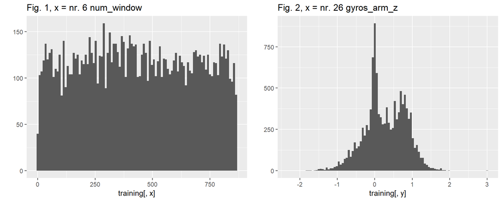

- Fig. 1 shows the values distribution of the *num_window* variable, a bit of a mysterious variable amongst all other physical-movement related ones. It is noted that the corresponding values in the BlindTest data set reveal an almost identical distribution to that of the BaseData set. Codebook info is lacking to judge this variable, so it’s left in the data set.  
- Fig. 2 shows a typical value distribution for one of the physical movement-related variables. Most others show similar distributions.

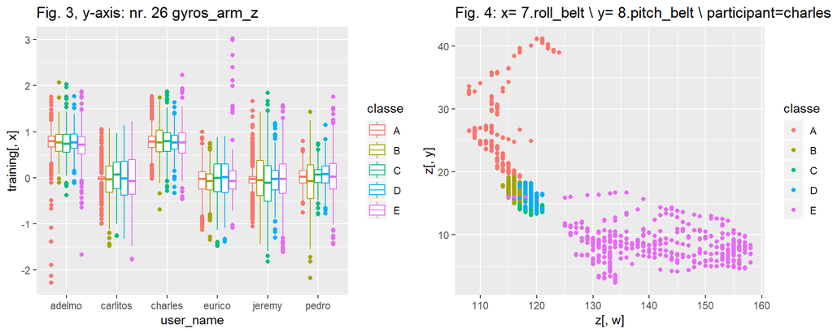

- Fig. 3 illustrates not only the noisiness of the data but also the fact that the measurement outcomes may be very participant-specific.  
- Fig. 4 shows how a combination of variables for a specific participant (*user_name*=charles), may provide for unambiguous classifications of the activities.

The last two figures show data-noisiness with presumably weak predictors and participant-specific measurements. This suggests a booster prediction modeling technique, to boost the weak predictors, in combination with a classification tree-based model seperating the six participants.

### Prediction Modeling

The target accuray shall be such that the total number of 20 BlindTest (PMLtesting) cases, are predicted with an overall accuracy of at least 80%. This requires a model accuray of at least 98.9%: (0.989)^20 = 0.800

A random forest model is investigated using the `train` function of the `caret` library. [Course mentor info](https://github.com/lgreski/datasciencectacontent/blob/master/markdown/pml-randomForestPerformance.md) provides valuable advise regarding the use of parallel computing and function parameter settings to avoid excessive elapsed times.  
The parameters are set using the `trainControl` function. The most critical arguments for the trainControl function are the resampling method `method`, the `number` that specifies the quantity of folds for k-fold cross-validation, and `allowParallel` which tells caret to use the specified number of clusters. A 5 k-fold cross-validation model is advised.

The random forest model is run and the confusionMatrix compares the *testing* dataframe *classe* values with the model’s predictions.

```r
set.seed(1000)

mTrain <- select(training, -(index), -(raw_timestamp_part_1:cvtd_timestamp))
# Excluding the index and timestamp variables.
cluster <- makeCluster(detectCores() - 1) # convention to leave 1 core for OS
registerDoParallel(cluster)

fitControl <- trainControl(method = "cv", number = 5, allowParallel = TRUE)
# 'method' and 'number' per Course mentor advise.

system.time(
modFit_rf <- train(classe ~ . , method="rf", trControl=fitControl, data=mTrain, verbose=FALSE)
)
```

```
##    user  system elapsed
##   49.25    0.74  435.54
```

```r
stopCluster(cluster)    # Shuting down the clustering.
registerDoSEQ()         # Forcing R to return to single threaded processing.

predFit_rf <- predict(modFit_rf, testing)
confusionMatrix(testing$classe, predFit_rf)
```

```
## Confusion Matrix and Statistics
##
##           Reference
## Prediction    A    B    C    D    E
##          A 1115    1    0    0    0
##          B    1  757    0    1    0
##          C    0    0  684    0    0
##          D    0    0    1  642    0
##          E    0    1    0    5  715
##
## Overall Statistics
##
##                Accuracy : 0.9975
##                  95% CI : (0.9953, 0.9988)
##     No Information Rate : 0.2845
##     P-Value [Acc > NIR] : < 2.2e-16
##
##                   Kappa : 0.9968
##  Mcnemar's Test P-Value : NA
##
## Statistics by Class:
##
##                      Class: A Class: B Class: C Class: D Class: E
## Sensitivity            0.9991   0.9974   0.9985   0.9907   1.0000
## Specificity            0.9996   0.9994   1.0000   0.9997   0.9981
## Pos Pred Value         0.9991   0.9974   1.0000   0.9984   0.9917
## Neg Pred Value         0.9996   0.9994   0.9997   0.9982   1.0000
## Prevalence             0.2845   0.1935   0.1746   0.1652   0.1823
## Detection Rate         0.2842   0.1930   0.1744   0.1637   0.1823
## Detection Prevalence   0.2845   0.1935   0.1744   0.1639   0.1838
## Balanced Accuracy      0.9994   0.9984   0.9993   0.9952   0.9991
```

**Conclusion** The random forest model’s out of sample accuracy equals 0.997. This exceeds the required 0.989 level. This model is therefore not only the first, but also the final one.  
The model happens to predict all 20 BlindTest cases correctly (ref. the week 4 quiz outcomes).

-/-